# Tidy Data

```r
library(tidyverse)
library(babynames)

# Toy data
cases <- tribble(
  ~Country, ~"2011", ~"2012", ~"2013",
      "FR",    7000,    6900,    7000,
      "DE",    5800,    6000,    6200,
      "US",   15000,   14000,   13000
)

pollution <- tribble(
       ~city, ~size, ~amount,
  "New York", "large",      23,
  "New York", "small",      14,
    "London", "large",      22,
    "London", "small",      16,
   "Beijing", "large",     121,
   "Beijing", "small",     121
)

x <- tribble(
  ~x1, ~x2,
  "A",   1,
  "B",  NA,
  "C",  NA,
  "D",   3,
  "E",  NA
)

# To avoid a distracting detail during class
names(who) <- stringr::str_replace(names(who), "newrel", "new_rel")
```

## Your Turn 1

On a sheet of paper, draw how the cases data set would look if it had the same values grouped into three columns: **country**, **year**, **n**

## Your Turn 2

```r
## Your Turn 2
table4a %>%
  pivot_longer(-country,
                                names_to = "year", values_to = "count")
```

| country | year | count |
| --- | --- | --- |
| Afghanistan | 1999 | 745 |
| Afghanistan | 2000 | 2666 |
| Brazil | 1999 | 37737 |
| Brazil | 2000 | 80488 |
| China | 1999 | 212258 |
| China | 2000 | 213766 |

## Your Turn 3

On a sheet of paper, draw how this data set would look if it had the same values grouped into three columns: **city**, **large**, **small**

## Your Turn 4

Use `pivot_wider()` to reorganize `table2` into four columns: **country**, **year**, **cases**, and **population**.

```r
## Your Turn 4
table2 %>%
  pivot_wider(names_from = type,
                                values_from = count)
```

| country | year | cases | population |
| --- | --- | --- | --- |
| Afghanistan | 1999 | 745 | 19987071 |
| Afghanistan | 2000 | 2666 | 20595360 |
| Brazil | 1999 | 37737 | 172006362 |
| Brazil | 2000 | 80488 | 174504898 |
| China | 1999 | 212258 | 1272915272 |
| China | 2000 | 213766 | 1280428583 |

## Your Turn 5

Pivot the 5th through 60th columns of `who` into a key column: value column pair named **codes** and **n**. Then select just the `county`, `year`, `codes` and `n` variables.

In the R code chunks below I have used the `head()` function as the datasets are generally large. This reduces the size of the output HTML file. The solution to the Your Turn example will not require the use of `head()`.

```r
## Your Turn 5
who %>%
  pivot_longer(cols = 5:60, names_to="codes", values_to="n") %>%
  select(-iso2, -iso3) %>%
  head()
```

| country | year | codes | n |
| --- | --- | --- | --- |
| Afghanistan | 1980 | new_sp_m014 | NA |
| Afghanistan | 1980 | new_sp_m1524 | NA |
| Afghanistan | 1980 | new_sp_m2534 | NA |
| Afghanistan | 1980 | new_sp_m3544 | NA |
| Afghanistan | 1980 | new_sp_m4554 | NA |
| Afghanistan | 1980 | new_sp_m5564 | NA |

## Your Turn 6

Separate the `sexage` column into **sex** and **age** columns.

```r
## Your Turn 6
who %>%
 pivot_longer(cols = 5:60, names_to="codes", values_to="n") %>%
 select(-iso2, -iso3) %>%
 separate(codes, c("new", "type", "sexage"), sep = "_") %>%
 select(-new) %>%
 separate(sexage, into = c("sex", "age"), sep = 1) %>%
  head()
```

| country | year | type | sex | age | n |
| --- | --- | --- | --- | --- | --- |
| Afghanistan | 1980 | sp | m | 014 | NA |
| Afghanistan | 1980 | sp | m | 1524 | NA |
| Afghanistan | 1980 | sp | m | 2534 | NA |
| Afghanistan | 1980 | sp | m | 3544 | NA |
| Afghanistan | 1980 | sp | m | 4554 | NA |
| Afghanistan | 1980 | sp | m | 5564 | NA |

## Check your understanding

Reshape the layout of this data. Calculate the percent of male (or female) children by year. Then plot the percent over time.

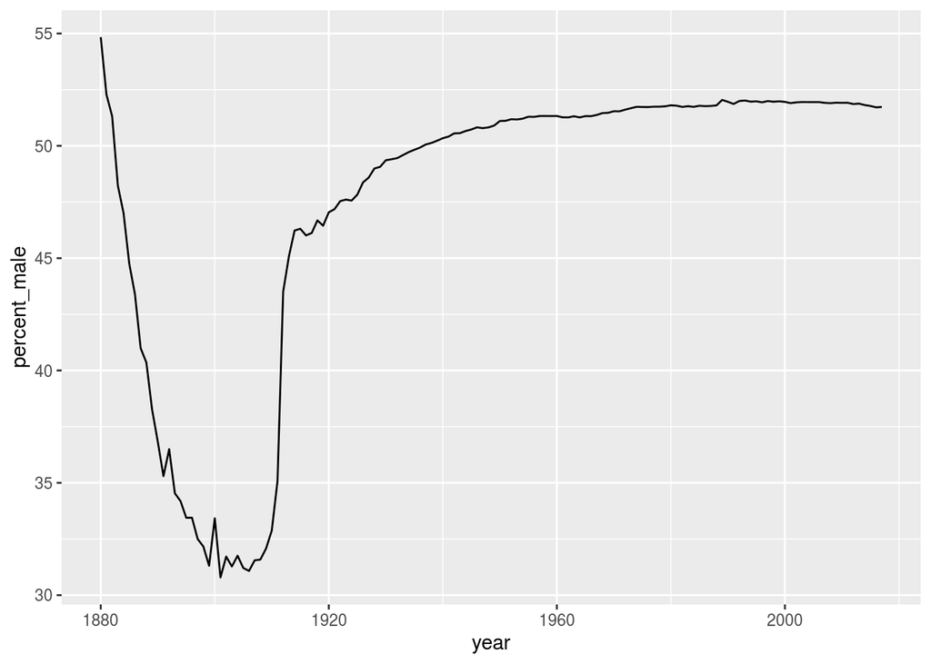

```r
## Check your understanding
babynames %>%
  group_by(year, sex) %>%
  summarise(n = sum(n)) %>%
  pivot_wider(names_from = sex, values_from = n) %>%
  mutate(percent_male = M / (M + F) * 100) %>%
  ggplot(aes(year, percent_male)) + geom_line()
```

## Appendix 1 - all code used in this training

```r
library(tidyverse)
library(babynames)

# Toy data
cases <- tribble(
  ~Country, ~"2011", ~"2012", ~"2013",
      "FR",    7000,    6900,    7000,
      "DE",    5800,    6000,    6200,
      "US",   15000,   14000,   13000
)

pollution <- tribble(
       ~city, ~size, ~amount,
  "New York", "large",      23,
  "New York", "small",      14,
    "London", "large",      22,
    "London", "small",      16,
   "Beijing", "large",     121,
   "Beijing", "small",     121
)

x <- tribble(
  ~x1, ~x2,
  "A",   1,
  "B",  NA,
  "C",  NA,
  "D",   3,
  "E",  NA
)

# To avoid a distracting detail during class
names(who) <- stringr::str_replace(names(who), "newrel", "new_rel")
## Your Turn 2
table4a %>%
  pivot_longer(-country,
                                names_to = "year", values_to = "count")

## Your Turn 4
table2 %>%
  pivot_wider(names_from = type,
                                values_from = count)

## Your Turn 5
who %>%
  pivot_longer(cols = 5:60, names_to="codes", values_to="n") %>%
  select(-iso2, -iso3) %>%
  head()

## Your Turn 6
who %>%
 pivot_longer(cols = 5:60, names_to="codes", values_to="n") %>%
 select(-iso2, -iso3) %>%
 separate(codes, c("new", "type", "sexage"), sep = "_") %>%
 select(-new) %>%
 separate(sexage, into = c("sex", "age"), sep = 1) %>%
  head()

## Check your understanding
babynames %>%
  group_by(year, sex) %>%
  summarise(n = sum(n)) %>%
  pivot_wider(names_from = sex, values_from = n) %>%
  mutate(percent_male = M / (M + F) * 100) %>%
  ggplot(aes(year, percent_male)) + geom_line()
```